# numpy

```python
import numpy
numpy.__version__
```

```
'1.20.3'
```

```python
import numpy as np
```

```python
# help(numpy)
```

```python
%paste
```

```
UsageError: Line magic function `%paste` not found.
```

## 2.1.2 Python列表不仅仅是一个列表

```python
L = list(range(10))
L
```

```
[0, 1, 2, 3, 4, 5, 6, 7, 8, 9]
```

```python
type(L[0])
```

```
int
```

```python
L2=list(str(c) for c in L)
L2
```

```
['0', '1', '2', '3', '4', '5', '6', '7', '8', '9']
```

```python
type(L2[0])
```

```
str
```

```python
# 因为 Python 的动态类型特性，甚至可以创建一个异构的列表：
L3 = [True, "2", 3.0, 4]
[type(item) for item in L3]
```

```
[bool, str, float, int]
```

列表和numpy数组的区别： 列表中的元素可以是不同类型，是“灵活”的

但是numpy中的元素必须是同一类型，numpy实际上是c列表

列表的优势是灵活，因为每个列表元素是一个包含数据和类型信息 的完整结构体，而且列表可以用任意类型的数据填充。固定类型的 NumPy 式数组缺乏这 种灵活性，但是能更有效地存储和操作数据。

## 2.1.3 Python中的固定类型数组

内置的数组（array）模块（在 Python 3.3 之后可用）可以用于创建统一类型的密集数组：

```python
import array
L = list(range(10))
A = array.array('i', L)
A
```

```
array('i', [0, 1, 2, 3, 4, 5, 6, 7, 8, 9])
```

这里的 'i' 是一个数据类型码，表示数据为整型。

更实用的是 NumPy 包中的 ndarray 对象。

## 2.1.4 从Python列表创建数组

首先，可以用 np.array 从 Python 列表创建数组：

```python
# 整型数组:
np.array([1, 4, 2, 5, 3])
```

```
array([1, 4, 2, 5, 3])
```

请记住，不同于 Python 列表， NumPy 要求数组必须包含同一类型的数据。如果类型不匹 配， NumPy 将会向上转换（如果可行）。这里整型被转换为浮点型：

```python
np.array([3.14, 4, 2, 3])
```

```
array([3.14, 4.  , 2.  , 3.  ])
```

如果希望明确设置数组的数据类型，可以用 dtype 关键字：

```python
np.array([1, 2, 3, 4], dtype='float32')
```

```
array([1., 2., 3., 4.], dtype=float32)
```

最后，不同于 Python 列表， NumPy 数组可以被指定为多维的。以下是用列表的列表初始 化多维数组的一种方法

```python
# 嵌套列表构成的多维数组
np.array([range(i, i + 3) for i in [2, 4, 6]])
```

```
array([[2, 3, 4],
       [4, 5, 6],
       [6, 7, 8]])
```

内层的列表被当作二维数组的行。

## 2.1.5 从头创建数组

```python
# 创建一个长度为10的数组，数组的值都是0
np.zeros(10, dtype=int)
```

```
array([0, 0, 0, 0, 0, 0, 0, 0, 0, 0])
```

```python
 # 创建一个3× 5的浮点型数组，数组的值都是1
np.ones((3, 5), dtype=float)
```

```
array([[1., 1., 1., 1., 1.],
       [1., 1., 1., 1., 1.],
       [1., 1., 1., 1., 1.]])
```

```python
# 创建一个3× 5的浮点型数组，数组的值都是3.14
np.full((3, 5), 3.14)
```

```
array([[3.14, 3.14, 3.14, 3.14, 3.14],
       [3.14, 3.14, 3.14, 3.14, 3.14],
       [3.14, 3.14, 3.14, 3.14, 3.14]])
```

```python
 # 创建一个3× 5的浮点型数组，数组的值是一个线性序列
# 从0开始，到20结束，步长为2
# （它和内置的range()函数类似）
np.arange(0, 20, 2)
```

```
array([ 0,  2,  4,  6,  8, 10, 12, 14, 16, 18])
```

```python
# 创建一个5个元素的数组，这5个数均匀地分配到0~1
np.linspace(0, 1, 5)
```

```
array([0.  , 0.25, 0.5 , 0.75, 1.  ])
```

```python
 # 创建一个3× 3的、在0~1均匀分布的随机数组成的数组
np.random.random((3, 3))
```

```
array([[0.22644898, 0.29264144, 0.42889986],
       [0.57850681, 0.86788676, 0.18375504],
       [0.06881626, 0.99239978, 0.83535134]])
```

```python
# 创建一个3× 3的、均值为0、方差为1的
# 正态分布的随机数数组
np.random.normal(0, 1, (3, 3))
```

```
array([[-0.95264121,  1.27966405,  0.59143278],
       [-0.56989652, -0.29860931,  1.72608615],
       [ 0.90354704, -0.72249351, -0.21936367]])
```

```python
# 创建一个3× 3的、 [0, 10)区间的随机整型数组
np.random.randint(0, 10, (3, 3))
```

```
array([[9, 3, 9],
       [3, 0, 2],
       [9, 4, 7]])
```

```python
# 创建一个3× 3的单位矩阵
np.eye(3)
```

```
array([[1., 0., 0.],
       [0., 1., 0.],
       [0., 0., 1.]])
```

```python
# 创建一个由3个整型数组成的未初始化的数组
# 数组的值是内存空间中的任意值
np.empty(3)
```

```
array([1., 1., 1.])
```

## 2.1.6 NumPy标准数据类型

请注意，当构建一个数组时，你可以用一个字符串参 数来指定数据类型：

```python
np.zeros(10, dtype='int16')
```

```
array([0, 0, 0, 0, 0, 0, 0, 0, 0, 0], dtype=int16)
```

或者用相关的 NumPy 对象来指定：

```python
np.zeros(10, dtype=np.int16)
```

```
array([0, 0, 0, 0, 0, 0, 0, 0, 0, 0], dtype=int16)
```

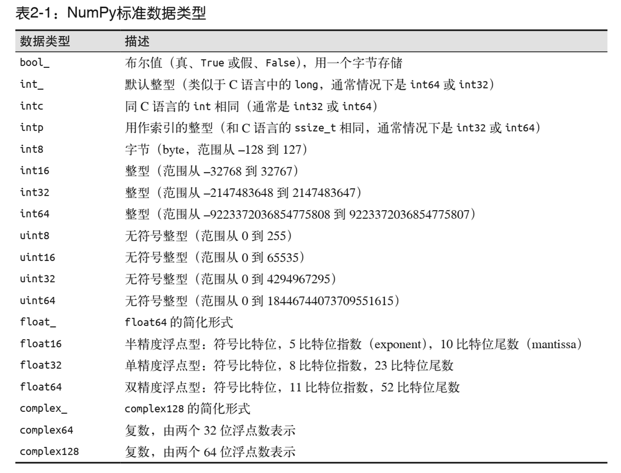

# 2.2 NumPy数组基础

本节将展示一些用 NumPy 数组操作获取数 据或子数组，对数组进行分裂、变形和连接的例子。

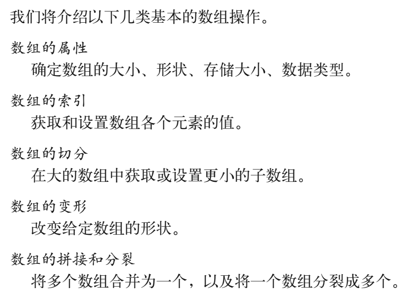

## 2.2.1 NumPy数组的属性

首先介绍一些有用的数组属性。

```python
# 定义三个随机的数组：一个一维数组、一个二维数组和一个三维数组。
#我们将用 NumPy 的随机数生成器设置一组种子值，以确保每次程序执行时都可以生成同样的随机数组：
import numpy as np
np.random.seed(0) # 设置随机数种子

x1 = np.random.randint(10, size=6) # 一维数组
x2 = np.random.randint(10, size=(3, 4)) # 二维数组
x3 = np.random.randint(10, size=(3, 4, 5)) # 三维数组
```

每个数组有 nidm（数组的维度）、 shape（数组每个维度的大小）和size（数组的总大小）属性：

```python
print("x3 ndim: ", x3.ndim)
print("x3 shape:", x3.shape)
print("x3 size: ", x3.size)
```

```
x3 ndim:  3
x3 shape: (3, 4, 5)
x3 size:  60
```

另外一个有用的属性是 dtype，它是数组的数据类型

其他的属性包括表示每个数组元素字节大小的 itemsize，以及表示数组总字节大小的属性 nbytes：

```python
print("itemsize:", x3.itemsize, "bytes")
print("nbytes:", x3.nbytes, "bytes")
```

```
itemsize: 4 bytes
nbytes: 240 bytes
```

一般来说，可以认为 nbytes 跟 itemsize 和 size 的乘积大小相等。

## 2.2.2 数组索引： 获取单个元素

```python
x1
```

```
array([5, 0, 3, 3, 7, 9])
```

```python
x1[0]
```

```
5
```

```python
x1[4]
```

```
7
```

为了获取数组的末尾索引，可以用负值索引：

```python
x1[-1]
```

```
9
```

```python
x1[-2]
```

```
7
```

在多维数组中，可以用逗号分隔的索引元组获取元素：

```python
x2
```

```
array([[3, 5, 2, 4],
       [7, 6, 8, 8],
       [1, 6, 7, 7]])
```

```python
x2[0, 0]
```

```
3
```

```python
x2[2, 0]
```

```
1
```

```python
x2[2, -1]
```

```
7
```

也可以用以上索引方式修改元素值：

```python
x2[0, 0] = 12
x2
```

```
array([[12,  5,  2,  4],
       [ 7,  6,  8,  8],
       [ 1,  6,  7,  7]])
```

NumPy 数组是固定类型的。这意味着当你试图将一个浮点 值插入一个整型数组时，浮点值会被截短成整型。并且这种截短是自动完成的，不会给你 提示或警告，所以需要特别注意这一点！

```python
x1[0] = 3.14159 # 这将被截短
x1
```

```
array([3, 0, 3, 3, 7, 9])
```

## 2.2.3 数组切片： 获取子数组

我们也可以用切片（slice）符号获取子数组，切片 符号用冒号（:）表示

x[start:stop:step]

1. 一维子数组

```python
x = np.arange(10)
x
```

```
array([0, 1, 2, 3, 4, 5, 6, 7, 8, 9])
```

```python
x[:5] # 前五个元素
```

```
array([0, 1, 2, 3, 4])
```

```python
x[5:] # 索引五之后的元素
```

```
array([5, 6, 7, 8, 9])
```

```python
x[4:7] # 中间的子数组
```

```
array([4, 5, 6])
```

```python
x[::2] # 每隔一个元素
```

```
array([0, 2, 4, 6, 8])
```

```python
x[1::2] # 每隔一个元素，从索引1开始
```

```
array([1, 3, 5, 7, 9])
```

你可能会在步长值为负时感到困惑。在这个例子中， start 参数和 stop 参数默认是被交换的。 因此这是一种非常方便的逆序数组的方式

```python
x[::-1] # 所有元素，逆序的
```

```
array([9, 8, 7, 6, 5, 4, 3, 2, 1, 0])
```

```python
x[5::-2] # 从索引5开始每隔一个元素逆序
```

```
array([5, 3, 1])
```

1. 多维子数组

多维切片也采用同样的方式处理，用冒号分隔。例如：

```python
x2
```

```
array([[12,  5,  2,  4],
       [ 7,  6,  8,  8],
       [ 1,  6,  7,  7]])
```

```python
x2[:2, :3] # 两行，三列
```

```
array([[12,  5,  2],
       [ 7,  6,  8]])
```

```python
x2[:3, ::2] # 所有行，每隔一列
```

```
array([[12,  2],
       [ 7,  8],
       [ 1,  7]])
```

最后，子数组维度也可以同时被逆序：

```python
 x2[::-1, ::-1]
```

```
array([[ 7,  7,  6,  1],
       [ 8,  8,  6,  7],
       [ 4,  2,  5, 12]])
```

1. 获取数组的行和列

一种常见的需求是获取数组的单行和单列。你可以将索引与切片组合起来实现这个功能， 用一个冒号（:）表示空切片：

```python
print(x2[:, 0]) # x2的第一列
```

```
[12  7  1]
```

```python
print(x2[0, :]) # x2的第一行
```

```
[12  5  2  4]
```

在获取行时，出于语法的简介考虑，可以省略空的切片

```python
print(x2[0]) #等于x2[0, :]
```

```
[12  5  2  4]
```

1. 非副本视图的子数组

关于数组切片有一点很重要也非常有用，那就是数组切片返回的是数组数据的视图，而 不是数值数据的副本。这一点也是 NumPy 数组切片和 Python 列表切片的不同之处：在 Python 列表中，切片是值的副本。例如此前示例中的那个二维数组：

```python
print(x2)
```

```
[[12  5  2  4]
 [ 7  6  8  8]
 [ 1  6  7  7]]
```

```python
# 从中抽取一个 2× 2 的子数组：
x2_sub = x2[:2, :2]
print(x2_sub)
```

```
[[12  5]
 [ 7  6]]
```

现在如果修改这个子数组，将会看到原始数组也被修改了！

```python
x2_sub[0, 0] = 99
print(x2_sub)
```

```
[[99  5]
 [ 7  6]]
```

```python
 print(x2)
```

```
[[99  5  2  4]
 [ 7  6  8  8]
 [ 1  6  7  7]]
```

1. 创建数组的副本

尽管数组视图有一些非常好的特性，但是在有些时候明确地复制数组里的数据或子数组也 是非常有用的。可以很简单地通过 copy() 方法实现：

```python
x2_sub_copy = x2[:2, :2].copy()
print(x2_sub_copy)
```

```
[[99  5]
 [ 7  6]]
```

```python
# 如果修改这个子数组，原始的数组不会被改变：
x2_sub_copy[0, 0] = 42
print(x2_sub_copy)
```

```
[[42  5]
 [ 7  6]]
```

```python
 print(x2)
```

```
[[99  5  2  4]
 [ 7  6  8  8]
 [ 1  6  7  7]]
```

## 2.2.4 数组的变形

数组变形最灵活的实现方式是通过 reshape() 函数 来实现。

```python
# 如果你希望将数字 1~9 放入一个 3× 3 的矩阵中
grid = np.arange(1, 10).reshape((3, 3))
print(grid)
```

```
[[1 2 3]
 [4 5 6]
 [7 8 9]]
```

如果希望该方法可行，那么原始数组的大小必须和变形后数组的大小一致。

另外一个常见的变形模式是将一个一维数组转变为二维的行或列的矩阵。你也可以通过 reshape 方法来实现，或者更简单地在一个切片操作中利用 newaxis 关键字：

```python
 x = np.array([1, 2, 3])
# 通过变形获得的行向量
x.reshape((1, 3))
```

```
array([[1, 2, 3]])
```

```python
# 通过newaxis获得的行向量
x[np.newaxis, :]
```

```
array([[1, 2, 3]])
```

```python
# 通过变形获得的列向量
x.reshape((3, 1))
```

```
array([[1],
       [2],
       [3]])
```

```python
 # 通过newaxis获得的列向量
x[:, np.newaxis]
```

```
array([[1],
       [2],
       [3]])
```

## 2.2.5 数组拼接和分裂

1. 数组的拼接

拼接或连接 NumPy 中的两个数组主要由 np.concatenate、 np.vstack 和 np.hstack 例程实 现。

np.concatenate 将数组元组或数组列表作为第一个参数

```python
 x = np.array([1, 2, 3])
y = np.array([3, 2, 1])
np.concatenate([x, y])
```

```
array([1, 2, 3, 3, 2, 1])
```

你也可以一次性拼接两个以上数组：

```python
z = [99, 99, 99]
print(np.concatenate([x, y, z]))
```

```
[ 1  2  3  3  2  1 99 99 99]
```

np.concatenate 也可以用于二维数组的拼接：

```python
grid = np.array([[1, 2, 3],
[4, 5, 6]])
```

```python
# 沿着第一个轴拼接
np.concatenate([grid, grid])
```

```
array([[1, 2, 3],
       [4, 5, 6],
       [1, 2, 3],
       [4, 5, 6]])
```

```python
# 沿着第二个轴拼接（从0开始索引）
np.concatenate([grid, grid], axis=1)
```

```
array([[1, 2, 3, 1, 2, 3],
       [4, 5, 6, 4, 5, 6]])
```

沿着固定维度处理数组时，使用 np.vstack（垂直栈）和 np.hstack（水平栈）函数会 更简洁：

```python
 x = np.array([1, 2, 3])
grid = np.array([[9, 8, 7],
[6, 5, 4]])
# 垂直栈数组
np.vstack([x, grid])
```

```
array([[1, 2, 3],
       [9, 8, 7],
       [6, 5, 4]])
```

```python
# 水平栈数组
y = np.array([[99],
[99]])
np.hstack([grid, y])
```

```
array([[ 9,  8,  7, 99],
       [ 6,  5,  4, 99]])
```

与之类似， np.dstack 将沿着第三个维度拼接数组

1. 数组的分裂

与拼接相反的过程是分裂。分裂可以通过 np.split、 np.hsplit 和 np.vsplit 函数来实现

可以向以上函数传递一个索引列表作为参数，索引列表记录的是分裂点位置：

```python
 x = [1, 2, 3, 99, 99, 3, 2, 1]
x1, x2, x3 = np.split(x, [3, 5])
print(x1, x2, x3)
```

```
[1 2 3] [99 99] [3 2 1]
```

值得注意的是， N 分裂点会得到 N + 1 个子数组。相关的 np.hsplit 和 np.vsplit 的用法也 类似：

```python
grid = np.arange(16).reshape((4, 4))
grid
```

```
array([[ 0,  1,  2,  3],
       [ 4,  5,  6,  7],
       [ 8,  9, 10, 11],
       [12, 13, 14, 15]])
```

```python
upper, lower = np.vsplit(grid, [2])
print(upper)
print(lower)
```

```
[[0 1 2 3]
 [4 5 6 7]]
[[ 8  9 10 11]
 [12 13 14 15]]
```

```python
left, right = np.hsplit(grid, [2])
print(left)
print(right)
```

```
[[ 0  1]
 [ 4  5]
 [ 8  9]
 [12 13]]
[[ 2  3]
 [ 6  7]
 [10 11]
 [14 15]]
```

np.dsplit 将数组沿着第三个维度分裂。

# 2.3 NumPy数组的计算： 通用函数

NumPy 提供了一个简单 灵活的接口来优化数据数组的计算

使 NumPy 变快的关键是利用向量化操作， 通常在 NumPy 的通用函数（ufunc）中实现。

## 2.3.1 缓慢的循环

数据类型灵活的特性决定了序列操作不能像 C 语言和 Fortran 语言 一样被编译成有效的机器码。

Python 的相对缓慢通常出现在很多小操作需要不断重复的时候，比如对数组的每个元素做 循环操作时。

```python
# 假设有一个数组，我们想计算每个元素的倒数，一种直接的解决方法是
import numpy as np
np.random.seed(0)
def compute_reciprocals(values):
    output = np.empty(len(values))
    for i in range(len(values)):
        output[i] = 1.0 / values[i]
    return output
values = np.random.randint(1, 10, size=5)
compute_reciprocals(values)
```

```
array([0.16666667, 1.        , 0.25      , 0.25      , 0.125     ])
```

```python
big_array = np.random.randint(1, 100, size=1000000)
%timeit compute_reciprocals(big_array)
```

```
2.43 s ± 54.2 ms per loop (mean ± std. dev. of 7 runs, 1 loop each)
```

事实上，这里的处理瓶颈并不是运算本身，而是 CPython 在每次循环时必须做数据类 型的检查和函数的调度。每次进行倒数运算时， Python 首先检查对象的类型，并且动态查 找可以使用该数据类型的正确函数。如果我们在编译代码时进行这样的操作，那么就能在 代码执行之前知晓类型的声明，结果的计算也会更加有效率。

## 2.3.2 通用函数介绍

NumPy 为很多类型的操作提供了非常方便的、静态类型的、可编译程序的接口，也被称作 向量操作。你可以通过简单地对数组执行操作来实现，这里对数组的操作将会被用于数组 中的每一个元素。这种向量方法被用于将循环推送至 NumPy 之下的编译层，这样会取得 更快的执行效率。

```python
print(compute_reciprocals(values))
print(1.0 / values)
```

```
[0.16666667 1.         0.25       0.25       0.125     ]
[0.16666667 1.         0.25       0.25       0.125     ]
```

```python
# 如果计算一个较大数组的运行时间，可以看到它的完成时间比 Python 循环花费的时间更短：
%timeit (1.0 / big_array)
```

```
4.48 ms ± 103 µs per loop (mean ± std. dev. of 7 runs, 100 loops each)
```

NumPy 中的向量操作是通过通用函数实现的。通用函数的主要目的是对 NumPy 数组中的 值执行更快的重复操作。它非常灵活，前面我们看过了标量和数组的运算，但是也可以对 两个数组进行运算

```python
np.arange(5) / np.arange(1, 6)
```

```
array([0.        , 0.5       , 0.66666667, 0.75      , 0.8       ])
```

通用函数并不仅限于一维数组的运算，它们也可以进行多维数组的运算：

```python
x = np.arange(9).reshape((3, 3))
2 ** x
```

```
array([[  1,   2,   4],
       [  8,  16,  32],
       [ 64, 128, 256]], dtype=int32)
```

## 2.3.3 探索NumPy的通用函数

通用函数有两种存在形式： 一元通用函数（unary ufunc）对单个输入操作， 二元通用函数 （binary ufunc）对两个输入操作

1. 数组的运算

```python
x = np.arange(4)
print("x =", x)
print("x + 5 =", x + 5)
print("x - 5 =", x - 5)
print("x * 2 =", x * 2)
print("x / 2 =", x / 2)
print("x // 2 =", x // 2) #地板除法运算
```

```
x = [0 1 2 3]
x + 5 = [5 6 7 8]
x - 5 = [-5 -4 -3 -2]
x * 2 = [0 2 4 6]
x / 2 = [0.  0.5 1.  1.5]
x // 2 = [0 0 1 1]
```

还有逻辑非、 ** 表示的指数运算符和 % 表示的模运算符的一元通用函数：

```python
print("-x = ", -x)
print("x ** 2 = ", x ** 2)
print("x % 2 = ", x % 2)
```

```
-x =  [ 0 -1 -2 -3]
x ** 2 =  [0 1 4 9]
x % 2 =  [0 1 0 1]
```

你可以任意将这些算术运算符组合使用。当然，你得考虑这些运算符的优先级：

```python
-(0.5*x + 1) ** 2
```

```
array([-1.  , -2.25, -4.  , -6.25])
```

所有这些算术运算符都是 NumPy 内置函数的简单封装器，例如 + 运算符就是一个 add 函 数的封装器：

```python
np.add(x, 2)
```

```
array([2, 3, 4, 5])
```

表 2-2 列出了所有 NumPy 实现的算术运算符。

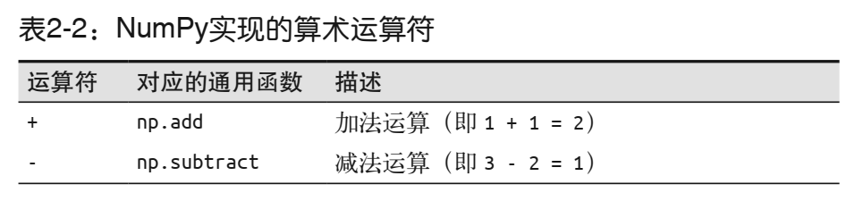

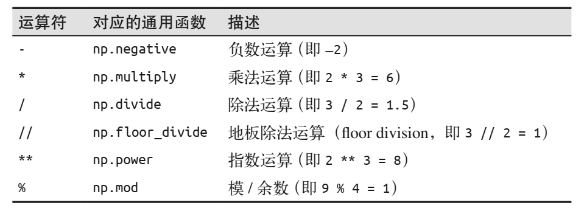

1. 绝对值

```python
x = np.array([-2, -1, 0, 1, 2])
abs(x)
```

```
array([2, 1, 0, 1, 2])
```

对应的 NumPy 通用函数是 np.absolute，该函数也可以用别名 np.abs 来访问：

```python
np.absolute(x)
```

```
array([2, 1, 0, 1, 2])
```

```python
np.abs(x)
```

```
array([2, 1, 0, 1, 2])
```

这个通用函数也可以处理复数。当处理复数时，绝对值返回的是该复数的幅度：

```python
x = np.array([3 - 4j, 4 - 3j, 2 + 0j, 0 + 1j])
np.abs(x)
```

```
array([5., 5., 2., 1.])
```

1. 三角函数

```python
# 首先定义一个角度数组：
theta = np.linspace(0, np.pi, 3)
```

```python
print("theta = ", theta)
print("sin(theta) = ", np.sin(theta))
print("cos(theta) = ", np.cos(theta))
print("tan(theta) = ", np.tan(theta))
```

```
theta =  [0.         1.57079633 3.14159265]
sin(theta) =  [0.0000000e+00 1.0000000e+00 1.2246468e-16]
cos(theta) =  [ 1.000000e+00  6.123234e-17 -1.000000e+00]
tan(theta) =  [ 0.00000000e+00  1.63312394e+16 -1.22464680e-16]
```

逆三角函数同样 可以使用：

```python
x = [-1, 0, 1]
print("x = ", x)
print("arcsin(x) = ", np.arcsin(x))
print("arccos(x) = ", np.arccos(x))
print("arctan(x) = ", np.arctan(x))
```

```
x =  [-1, 0, 1]
arcsin(x) =  [-1.57079633  0.          1.57079633]
arccos(x) =  [3.14159265 1.57079633 0.        ]
arctan(x) =  [-0.78539816  0.          0.78539816]
```

1. 指数和对数

```python
x = [1, 2, 3]
print("x =", x)
print("e^x =", np.exp(x))
print("2^x =", np.exp2(x))
print("3^x =", np.power(3, x))
```

```
x = [1, 2, 3]
e^x = [ 2.71828183  7.3890561  20.08553692]
2^x = [2. 4. 8.]
3^x = [ 3  9 27]
```

指数运算的逆运算，即对数运算也是可用的。最基本的 np.log 给出的是以自然数为底数的 对数。如果你希望计算以 2 为底数或者以 10 为底数的对数，可以按照如下示例处理：

```python
 x = [1, 2, 4, 10]
print("x =", x)
print("ln(x) =", np.log(x))
print("log2(x) =", np.log2(x))
print("log10(x) =", np.log10(x))
```

```
x = [1, 2, 4, 10]
ln(x) = [0.         0.69314718 1.38629436 2.30258509]
log2(x) = [0.         1.         2.         3.32192809]
log10(x) = [0.         0.30103    0.60205999 1.        ]
```

还有一些特殊的版本，对于非常小的输入值可以保持较好的精度：

```python
x = [0, 0.001, 0.01, 0.1]
print("exp(x) - 1 =", np.expm1(x))
print("log(1 + x) =", np.log1p(x))
```

```
exp(x) - 1 = [0.         0.0010005  0.01005017 0.10517092]
log(1 + x) = [0.         0.0009995  0.00995033 0.09531018]
```

当 x 的值很小时，以上函数给出的值比 np.log 和 np.exp 的计算更精确

1. 专用的通用函数

NumPy 还提供了很多通用函数，包括双曲三角函数、比特位运算、比 较运算符、弧度转化为角度的运算、取整和求余运算，等等

还有一个更加专用，也更加晦涩的通用函数优异来源是子模块 scipy.special。如果你希 望对你的数据进行一些更晦涩的数学计算， scipy.special 可能包含了你需要的计算函数。 这些函数能列一个长长的列表，下面的代码片段展示了一些可能在统计学中用到的函数

```python
from scipy import special
```

```python
# Gamma函数（广义阶乘， generalized factorials）和相关函数
x = [1, 5, 10]
print("gamma(x) =", special.gamma(x))
print("ln|gamma(x)| =", special.gammaln(x))
print("beta(x, 2) =", special.beta(x, 2))
```

```
gamma(x) = [1.0000e+00 2.4000e+01 3.6288e+05]
ln|gamma(x)| = [ 0.          3.17805383 12.80182748]
beta(x, 2) = [0.5        0.03333333 0.00909091]
```

```python
 # 误差函数（高斯积分）
# 它的实现和它的逆实现
x = np.array([0, 0.3, 0.7, 1.0])
print("erf(x) =", special.erf(x))
print("erfc(x) =", special.erfc(x))
print("erfinv(x) =", special.erfinv(x))
```

```
erf(x) = [0.         0.32862676 0.67780119 0.84270079]
erfc(x) = [1.         0.67137324 0.32219881 0.15729921]
erfinv(x) = [0.         0.27246271 0.73286908        inf]
```

NumPy 和 scipy.special 中提供了大量的通用函数，这些包的文档在网上就可以查到，搜 索“gamma function python”即可。

## 2.3.4 高级的通用函数特性

1. 指定输出

在进行大量运算时，有时候指定一个用于存放运算结果的数组是非常有用的。不同于创建 临时数组，你可以用这个特性将计算结果直接写入到你期望的存储位置。所有的通用函数 都可以通过 out 参数来指定计算结果的存放位置：

```python
x = np.arange(5)
y = np.empty(5)
np.multiply(x, 10, out=y)
print(y)
```

```
[ 0. 10. 20. 30. 40.]
```

这个特性也可以被用作数组视图，例如可以将计算结果写入指定数组的每隔一个元素的 位置：

```python
y = np.zeros(10)
np.power(2, x, out=y[::2])
print(y)
```

```
[ 1.  0.  2.  0.  4.  0.  8.  0. 16.  0.]
```

如果这里写的是 y[::2] = 2 **x，那么结果将是创建一个临时数组，该数组存放的是 2** x 的结果，并且接下来会将这些值复制到 y 数组中。对于上述例子中比较小的计 算量来说，这两种方式的差别并不大。但是对于较大的数组，通过慎重使用 out 参数 将能够有效节约内存

1. 聚合

对 add 通用函数调用 reduce 方法会返回数组中所有元素的和：

```python
 x = np.arange(1, 6)
np.add.reduce(x)
```

```
15
```

对 multiply 通用函数调用 reduce 方法会返回数组中所有元素的乘积：

```python
np.multiply.reduce(x)
```

```
120
```

如果需要存储每次计算的中间结果，可以使用 accumulate：

```python
 np.add.accumulate(x)
```

```
array([ 1,  3,  6, 10, 15], dtype=int32)
```

```python
 np.multiply.accumulate(x)
```

```
array([  1,   2,   6,  24, 120], dtype=int32)
```

请注意，在一些特殊情况中， NumPy 提供了专用的函数（np.sum、 np.prod、 np.cumsum、 np.cumprod ） ，它们也可以实现以上 reduce 的功能，

1. 外积

最后，任何通用函数都可以用 outer 方法获得两个不同输入数组所有元素对的函数运算结 果。这意味着你可以用一行代码实现一个乘法表：

```python
x = np.arange(1, 6)
np.multiply.outer(x, x)
```

```
array([[ 1,  2,  3,  4,  5],
       [ 2,  4,  6,  8, 10],
       [ 3,  6,  9, 12, 15],
       [ 4,  8, 12, 16, 20],
       [ 5, 10, 15, 20, 25]])
```

2.7 节将介绍非常有用的 ufunc.at 和 ufunc.reduceat 方法。

通用函数另外一个非常有用的特性是它能操作不同大小和形状的数组，一组这样的操作被 称为广播（broadcasting）。

## 2.3.5 通用函数： 更多的信息

有关通用函数的更多信息（包括可用的通用函数的完整列表）可以在 NumPy（http://www. numpy.org）和 SciPy（http://www.scipy.org）文档的网站找到

# 2.4 聚合： 最小值、 最大值和其他值

当你面对大量的数据时，第一个步骤通常都是计算相关数据的概括统计值。最常用的概括统 计值可能是均值和标准差，这两个值能让你分别概括出数据集中的“经典”值，但是其他一 些形式的聚合也是非常有用的（如求和、乘积、中位数、最小值和最大值、分位数，等等）。 NumPy 有非常快速的内置聚合函数可用于数组，我们将介绍其中的一些。

## 2.4.1 数组值求和

设想计算一个数组中所有元素的和。 Python 本身可用内置的 sum 函数 来实现：

```python
import numpy as np
```

```python
L = np.random.random(100)
print(L)
sum(L)
```

```
[0.86040711 0.22263363 0.91036365 0.99786145 0.95380043 0.14306525
 0.48237513 0.58497699 0.49493397 0.07985917 0.07440217 0.77125474
 0.52237254 0.80399623 0.59103809 0.62970797 0.35417538 0.27539307
 0.808583   0.08579555 0.92611747 0.5625609  0.25919535 0.43017383
 0.95912955 0.36717311 0.05840873 0.46238208 0.24706425 0.14887337
 0.83677774 0.6673714  0.74564099 0.80300142 0.08869286 0.49579085
 0.08747428 0.45633497 0.42772434 0.34162978 0.14185204 0.23340319
 0.30249017 0.68329343 0.2532048  0.52517627 0.67857527 0.50063566
 0.75416489 0.91245937 0.53626615 0.5878614  0.68194459 0.16282711
 0.52122371 0.79806309 0.61785649 0.99762158 0.66772712 0.71587407
 0.24713813 0.68047898 0.44446523 0.47988249 0.40389634 0.07891534
 0.67005652 0.77957591 0.91595211 0.81747149 0.27915835 0.83844191
 0.43999121 0.79538095 0.84864637 0.00249011 0.35308581 0.28659995
 0.79183986 0.47733026 0.28944954 0.11578003 0.17594778 0.85274372
 0.27567469 0.29618694 0.9692947  0.70257074 0.72384991 0.44129906
 0.38103313 0.81107321 0.11590284 0.59438408 0.77175439 0.11221741
 0.31887532 0.04550868 0.16555262 0.46632911]
```

```
50.54725838567564
```

```python
np.sum(L)
```

```
50.54725838567564
```

因为 NumPy 的 sum 函数在编译码中执行操作，所以 NumPy 的操作计算得更 快一些：

```python
big_array = np.random.rand(1000000)
%timeit sum(big_array)
%timeit np.sum(big_array)
```

```
86.2 ms ± 7.27 ms per loop (mean ± std. dev. of 7 runs, 10 loops each)
2.03 ms ± 133 µs per loop (mean ± std. dev. of 7 runs, 1,000 loops each)
```

sum 函数和 np.sum 函数并不等同，这有时会导致混淆。尤其是它们各自 的可选参数都有不同的含义， np.sum 函数是知道数组的维度的，这一点将在接下来的部 分讲解

## 2.4.2 最小值和最大值

Python 也有内置的 min 函数和 max 函数，分别被用于获取给定数组的最小值和最 大值：

```python
min(big_array), max(big_array)
```

```
(1.549734310879458e-07, 0.9999992887935267)
```

NumPy 对应的函数也有类似的语法，并且也执行得更快

```python
 np.min(big_array), np.max(big_array)
```

```
(1.549734310879458e-07, 0.9999992887935267)
```

```python
%timeit min(big_array)
%timeit np.min(big_array)
```

```
121 ms ± 26.4 ms per loop (mean ± std. dev. of 7 runs, 10 loops each)
951 µs ± 91.6 µs per loop (mean ± std. dev. of 7 runs, 1,000 loops each)
```

对于 min、 max、 sum 和其他 NumPy 聚合，一种更简洁的语法形式是数组对象直接调用这些 方法：

```python
print(big_array.min(), big_array.max(), big_array.sum())
```

```
1.549734310879458e-07 0.9999992887935267 499977.01125753426
```

1. 多维度聚合

一种常用的聚合操作是沿着一行或一列聚合。

```python
M = np.random.random((3, 4))
print(M)
```

```
[[0.21077071 0.60909654 0.08271359 0.02296035]
 [0.61046473 0.64741386 0.76643926 0.00115446]
 [0.75876097 0.52091294 0.62052165 0.18525981]]
```

默认情况下，每一个 NumPy 聚合函数将会返回对整个数组的聚合结果：

```python
M.sum()
```

```
5.036468865129254
```

聚合函数还有一个参数，用于指定沿着哪个轴的方向进行聚合。例如，可以通过指定 axis=0 找到每一列的最小值

```python
M.min(axis=0)
```

```
array([0.21077071, 0.52091294, 0.08271359, 0.00115446])
```

同样，也可以找到每一行的最大值：

```python
M.max(axis=1)
```

```
array([0.60909654, 0.76643926, 0.75876097])
```

1. 其他聚合函数

另外，大多数的聚合都 有对 NaN 值的安全处理策略（NaN-safe），即计算时忽略所有的缺失值，这些缺失值即特殊 的 IEEE 浮点型 NaN 值

表 2-3 提供了一个 NumPy 中可用的聚合函数的清单。

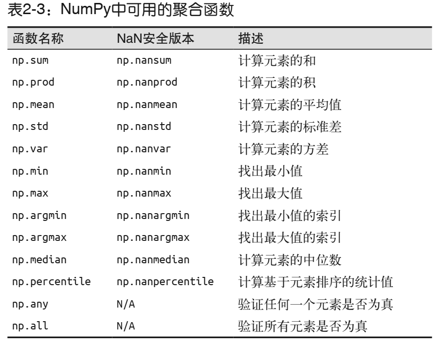

## 2.4.3 示例： 美国总统的身高是多少

```python
!head -4 'C:/Users/15354/Desktop/电子书/python/PythonDataScienceHandbook-master/notebooks/data/president_heights.csv'
```

```
order,name,height(cm)
1,George Washington,189
2,John Adams,170
3,Thomas Jefferson,189
```

```python
# 我们将用 Pandas 包来读文件并抽取身高信息。
import pandas as pd
data = pd.read_csv('C:/Users/15354/Desktop/电子书/python/PythonDataScienceHandbook-master/notebooks/data/president_heights.csv')
heights = np.array(data['height(cm)'])
print(heights)
```

```
[189 170 189 163 183 171 185 168 173 183 173 173 175 178 183 193 178 173
 174 183 183 168 170 178 182 180 183 178 182 188 175 179 183 193 182 183
 177 185 188 188 182 185]
```

```python
print("Mean height: ", heights.mean())
print("Standard deviation:", heights.std())
print("Minimum height: ", heights.min())
print("Maximum height: ", heights.max())
```

```
Mean height:  179.73809523809524
Standard deviation: 6.931843442745892
Minimum height:  163
Maximum height:  193
```

请注意，在这个例子中，聚合操作将整个数组缩减到单个概括值，这个概括值给出了这些 数值的分布信息。我们也可以计算分位数：

```python
print("25th percentile: ", np.percentile(heights, 25))
print("Median: ", np.median(heights))
print("75th percentile: ", np.percentile(heights, 75))
```

```
25th percentile:  174.25
Median:  182.0
75th percentile:  183.0
```

```python
# 通过 Matplotlib（第 4 章将详细讨论该工具）用以下代码创建图 2-3：
%matplotlib inline
import matplotlib.pyplot as plt
import seaborn; seaborn.set() # 设置绘图风格
```

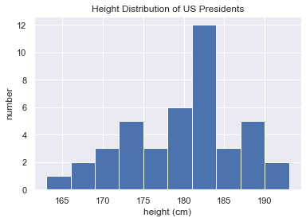

```python
plt.hist(heights)
plt.title('Height Distribution of US Presidents')
plt.xlabel('height (cm)')
plt.ylabel('number');
```

## 2.5 数组的计算： 广播

我们在前一节中介绍了 NumPy 如何通过通用函数的向量化操作来减少缓慢的 Python 循环， 另外一种向量化操作的方法是利用 NumPy 的广播功能。广播可以简单理解为用于不同大 小数组的二进制通用函数（加、减、乘等）的一组规则。

## 2.5.1 广播的介绍

对于同样大小的数组，二进制操作是对相应元素逐个计算。广播允许这些二进制操作可以用于不同大小的数组。

```python
import numpy as np
a = np.array([0, 1, 2])
b = np.array([5, 5, 5])
a + b
```

```
array([5, 6, 7])
```

```python
# 例如，可以简单地将一个标量（可以认为是一个零维的数组）和一个数组相加：
a + 5
```

```
array([5, 6, 7])
```

我们可以认为这个操作是将数值 5 扩展或重复至数组 [5, 5, 5]，然后执行加法。 NumPy 广播功能的好处是，这种对值的重复实际上并没有发生，但是这是一种很好用的理解广播 的模型

我们同样也可以将这个原理扩展到更高维度的数组。观察以下将一个一维数组和一个二维 数组相加的结果

```python
M = np.ones((3, 3))
M
```

```
array([[1., 1., 1.],
       [1., 1., 1.],
       [1., 1., 1.]])
```

```python
M + a
```

```
array([[1., 2., 3.],
       [1., 2., 3.],
       [1., 2., 3.]])
```

这里这个一维数组就被扩展或者广播了。它沿着第二个维度扩展，扩展到匹配 M 数组 的形状。

更复杂的情况会涉及对两个数组的同时广播，

```python
a = np.arange(3)
b = np.arange(3)[:, np.newaxis]
print(a)
print(b)
```

```
[0 1 2]
[[0]
 [1]
 [2]]
```

```python
a + b
```

```
array([[0, 1, 2],
       [1, 2, 3],
       [2, 3, 4]])
```

正如此前将一个值扩展或广播以匹配另外一个数组的形状，这里将 a 和 b 都进行了扩展来 匹配一个公共的形状，最终的结果是一个二维数组。

以上这些例子的几何可视化如图 2-4 所示。

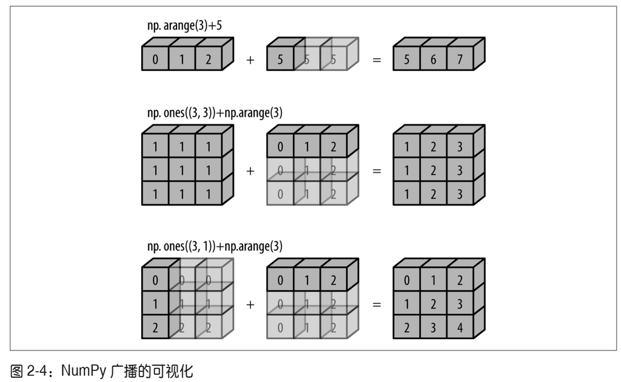

## 2.5.2 广播的规则

NumPy 的广播遵循一组严格的规则，设定这组规则是为了决定两个数组间的操作。

• 规则 1：如果两个数组的维度数不相同，那么小维度数组的形状将会在最左边补 1。

• 规则 2：如果两个数组的形状在任何一个维度上都不匹配，那么数组的形状会沿着维度 为 1 的维度扩展以匹配另外一个数组的形状。

• 规则 3：如果两个数组的形状在任何一个维度上都不匹配并且没有任何一个维度等于 1， 那么会引发异常。

1. 广播示例1

```python
# 将一个二维数组与一个一维数组相加：
M = np.ones((2, 3))
a = np.arange(3)

# 来看这两个数组的加法操作。两个数组的形状如下：
# M.shape = (2, 3)
# a.shape = (3,)
# 可以看到，根据规则 1，数组 a 的维度数更小，所以在其左边补 1：
# M.shape -> (2, 3)
# a.shape -> (1, 3)
# 根据规则 2，第一个维度不匹配，因此扩展这个维度以匹配数组：
# M.shape -> (2, 3)
# a.shape -> (2, 3)
# 现在两个数组的形状匹配了，可以看到它们的最终形状都为 (2, 3)：
M + a
```

```
array([[1., 2., 3.],
       [1., 2., 3.]])
```

1. 广播示例2

来看两个数组均需要广播的示例：

```python
a = np.arange(3).reshape((3, 1))
b = np.arange(3)
```

```python
a + b
```

```
array([[0, 1, 2],
       [1, 2, 3],
       [2, 3, 4]])
```

1. 广播示例3

```python
M = np.ones((3, 2))
a = np.arange(3)
```

如果你希望实现右边补全，可以通过变形数组来实 现（将会用到 np.newaxis 关键字

```python
 a[:, np.newaxis].shape
```

```
(3, 1)
```

```python
M + a[:, np.newaxis]
```

```
array([[1., 1.],
       [2., 2.],
       [3., 3.]])
```

另外也需要注意，这里仅用到了 + 运算符，而这些广播规则对于任意二进制通用函数都是 适用的。例如这里的 logaddexp(a, b) 函数，比起简单的方法，该函数计算 log(exp(a) + exp(b)) 更准确

```python
np.logaddexp(M, a[:, np.newaxis])
```

```
array([[1.31326169, 1.31326169],
       [1.69314718, 1.69314718],
       [2.31326169, 2.31326169]])
```

## 2.5.3 广播的实际应用

1. 数组的归一化

我们看到通用函数让 NumPy 用户免于写很慢的 Python 循环。广播进 一步扩展了这个功能，一个常见的例子就是数组数据的归一化。

```python
# 假设你有一个有 10 个观察值的数组，每个观察值包含 3 个数值。按照惯例（详情请参见 5.2 节），我们将用一个10× 3 的数组存放该数据：
X = np.random.random((10, 3))
```

```python
# 我们可以计算每个特征的均值，计算方法是利用 mean 函数沿着第一个维度聚合：
Xmean = X.mean(0)
Xmean
```

```
array([0.55666739, 0.50743427, 0.56555503])
```

```python
# 现在通过从 X 数组的元素中减去这个均值实现归一化（该操作是一个广播操作）：
X_centered = X - Xmean
```

```python
# 为了进一步核对我们的处理是否正确，可以查看归一化的数组的均值是否接近 0：
X_centered.mean(0)
```

```
array([ 0.00000000e+00,  4.44089210e-17, -1.11022302e-17])
```

1. 画一个二维函数

广播另外一个非常有用的地方在于，它能基于二维函数显示图像。

```python
# 我们希望定义一个函数z = f (x, y)，可以用广播沿着数值区间计算该函数：
# x和y表示0~5区间50个步长的序列
x = np.linspace(0, 5, 50)
y = np.linspace(0, 5, 50)[:, np.newaxis]
z = np.sin(x) ** 10 + np.cos(10 + y * x) * np.cos(x)
```

```python
x
```

```
array([0.        , 0.10204082, 0.20408163, 0.30612245, 0.40816327,
       0.51020408, 0.6122449 , 0.71428571, 0.81632653, 0.91836735,
       1.02040816, 1.12244898, 1.2244898 , 1.32653061, 1.42857143,
       1.53061224, 1.63265306, 1.73469388, 1.83673469, 1.93877551,
       2.04081633, 2.14285714, 2.24489796, 2.34693878, 2.44897959,
       2.55102041, 2.65306122, 2.75510204, 2.85714286, 2.95918367,
       3.06122449, 3.16326531, 3.26530612, 3.36734694, 3.46938776,
       3.57142857, 3.67346939, 3.7755102 , 3.87755102, 3.97959184,
       4.08163265, 4.18367347, 4.28571429, 4.3877551 , 4.48979592,
       4.59183673, 4.69387755, 4.79591837, 4.89795918, 5.        ])
```

```python
y
```

```
array([[0.        ],
       [0.10204082],
       [0.20408163],
       [0.30612245],
       [0.40816327],
       [0.51020408],
       [0.6122449 ],
       [0.71428571],
       [0.81632653],
       [0.91836735],
       [1.02040816],
       [1.12244898],
       [1.2244898 ],
       [1.32653061],
       [1.42857143],
       [1.53061224],
       [1.63265306],
       [1.73469388],
       [1.83673469],
       [1.93877551],
       [2.04081633],
       [2.14285714],
       [2.24489796],
       [2.34693878],
       [2.44897959],
       [2.55102041],
       [2.65306122],
       [2.75510204],
       [2.85714286],
       [2.95918367],
       [3.06122449],
       [3.16326531],
       [3.26530612],
       [3.36734694],
       [3.46938776],
       [3.57142857],
       [3.67346939],
       [3.7755102 ],
       [3.87755102],
       [3.97959184],
       [4.08163265],
       [4.18367347],
       [4.28571429],
       [4.3877551 ],
       [4.48979592],
       [4.59183673],
       [4.69387755],
       [4.79591837],
       [4.89795918],
       [5.        ]])
```

```python
z
```

```
array([[-0.83907153, -0.83470697, -0.8216586 , ...,  0.8956708 ,
         0.68617261,  0.41940746],
       [-0.83907153, -0.82902677, -0.8103873 , ...,  0.92522407,
         0.75321348,  0.52508175],
       [-0.83907153, -0.82325668, -0.79876457, ...,  0.96427357,
         0.84172689,  0.66446403],
       ...,
       [-0.83907153, -0.48233077, -0.01646558, ...,  0.96449925,
         0.75196531,  0.41982581],
       [-0.83907153, -0.47324558,  0.00392612, ...,  0.92542163,
         0.68540362,  0.37440839],
       [-0.83907153, -0.46410908,  0.02431613, ...,  0.89579384,
         0.65690314,  0.40107702]])
```

```python
# 我们将用 Matplotlib 来画出这个二维数组
%matplotlib inline
import matplotlib.pyplot as plt
```

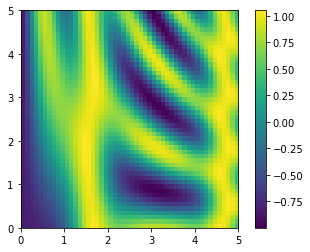

```python
plt.imshow(z, origin='lower', extent=[0, 5, 0, 5],cmap='viridis')
plt.colorbar();
```

# 2.6 比较、 掩码和布尔逻辑

这一节将会介绍如何用布尔掩码来查看和操作 NumPy 数组中的值。当你想基于某些准则 来抽取、修改、计数或对一个数组中的值进行其他操作时，掩码就可以派上用场了。例如 你可能希望统计数组中有多少值大于某一个给定值，或者删除所有超出某些门限值的异常 点。在 NumPy 中，布尔掩码通常是完成这类任务的最高效方式

# 2.6.1 示例： 统计下雨天数

```python
# 假设你有一系列表示某城市一年内日降水量的数据，这里将用 Pandas（将在第 3 章详细介绍）加载 2014 年西雅图市的日降水统计数据：
import numpy as np
import pandas as pd
# 利用Pandas抽取降雨量，放入一个NumPy数组
rainfall = pd.read_csv("C:/Users/15354/Desktop/电子书/python/PythonDataScienceHandbook-master/notebooks/data/Seattle2014.csv")['PRCP'].values
inches = rainfall / 254 # 1/10mm -> inches
inches.shape
```

```
(365,)
```

```python
# 首先做一个快速的可视化，用 Matplotlib（将在第 4 章详细讨论该工具）生成下雨天数的直方图
%matplotlib inline
import matplotlib.pyplot as plt
import seaborn;
seaborn.set() # 设置绘图风格
```

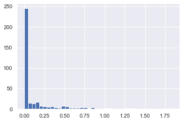

```python
plt.hist(inches, 40);
```

```python
# 例如一年中有多少天在下雨，这些下雨天的平均降水量是多少，有多少天的降水量超过了半英寸？
```

即对所有数据循环，当碰到数据落在 我们希望的区间时计数器便加 1。这种方法在本章节中多次讨论过，但无论从编写代码的 角度看，还是从计算结果的角度看，这都是一种浪费时间、非常低效的方法。我们从 2.3 节中了解到， NumPy 的通用函数可以用来替代循环，以快速实现数组的逐元素（elementwise）运算。同样，我们也可以用其他通用函数实现数组的逐元素比较，然后利用计算结果 回答之前提出的问题。先将数据放在一边，来介绍一下 NumPy 中有哪些用掩码来快速回 答这类问题的通用工具。

## 2.6.2 和通用函数类似的比较操作

介绍了通用函数，并且特别关注了算术运算符。我们看到用 +、 -、 *、 / 和其他一些 运算符实现了数组的逐元素操作。 NumPy 还实现了如 <（小于）和 >（大于）的逐元素比 较的通用函数。这些比较运算的结果是一个布尔数据类型的数组。一共有 6 种标准的比较 操作：

```python
x = np.array([1, 2, 3, 4, 5])
```

```python
x < 3 # 小于
```

```
array([ True,  True, False, False, False])
```

```python
x > 3 # 大于
```

```
array([False, False, False,  True,  True])
```

```python
x <= 3 # 小于等于
```

```
array([ True,  True,  True, False, False])
```

```python
 x >= 3 # 大于等于
```

```
array([False, False,  True,  True,  True])
```

```python
x != 3 # 不等于
```

```
array([ True,  True, False,  True,  True])
```

```python
x == 3 # 等于
```

```
array([False, False,  True, False, False])
```

另外，利用复合表达式实现对两个数组的逐元素比较也是可行的：

```python
 (2 * x) == (x ** 2)
```

```
array([False,  True, False, False, False])
```

和算术运算符一样，比较运算操作在 NumPy 中也是借助通用函数来实现的。例如当你写 x < 3 时， NumPy 内部会使用 np.less(x, 3)。这些比较运算符和其对应的通用函数如下 表所示。

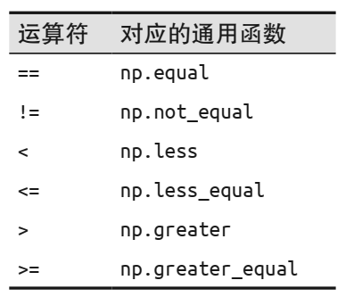

和算术运算通用函数一样，这些比较运算通用函数也可以用于任意形状、大小的数组。

```python
# 下面是一个二维数组的示例：
rng = np.random.RandomState(0)
x = rng.randint(10, size=(3, 4))
x
```

```
array([[5, 0, 3, 3],
       [7, 9, 3, 5],
       [2, 4, 7, 6]])
```

```python
x < 6
```

```
array([[ True,  True,  True,  True],
       [False, False,  True,  True],
       [ True,  True, False, False]])
```

## 2.6.3 操作布尔数组

给定一个布尔数组，你可以实现很多有用的操作。

```python
# 首先打印出此前生成的二维数组 x：
print(x)
```

```
[[5 0 3 3]
 [7 9 3 5]
 [2 4 7 6]]
```

1. 统计记录的个数

如果需要统计布尔数组中 True 记录的个数，可以使用 np.count_nonzero 函数：

```python
# 有多少值小于6？
np.count_nonzero(x < 6)
```

```
8
```

我们看到有 8 个数组记录是小于 6 的。另外一种实现方式是利用 np.sum。在这个例子中， False 会被解释成 0， True 会被解释成 1：

```python
 np.sum(x < 6)
```

```
8
```

sum() 的好处是，和其他 NumPy 聚合函数一样，这个求和也可以沿着行或列进行：

```python
# 每行有多少值小于6？
np.sum(x < 6, axis=1)
```

```
array([4, 2, 2])
```

如要快速检查任意或者所有这些值是否为 True，可以用（你一定猜到了） np.any() 或 np.all()：

```python
# 有没有值大于8？
np.any(x > 8)
```

```
True
```

```python
# 有没有值小于0？
np.any(x < 0)
```

```
False
```

```python
# 是否所有值都小于10？
np.all(x < 10)
```

```
True
```

```python
# 是否所有值都等于6？
np.all(x == 6)
```

```
False
```

np.all() 和 np.any() 也可以用于沿着特定的坐标轴

```python
 # 是否每行的所有值都小于8？
np.all(x < 8, axis=1)
```

```
array([ True, False,  True])
```

1. 布尔运算符

```python
 np.sum((inches > 0.5) & (inches < 1))
```

```
29
```

```python
# 可以用另外一种形式实现同样的结果
np.sum(~( (inches <= 0.5) | (inches >= 1) ))
```

```
29
```

以下表格总结了逐位的布尔运算符和其对应的通用函数。

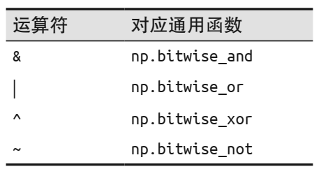

```python
# 利用这些工具，就可以回答那些关于天气数据的问题了。
print("Number days without rain: ", np.sum(inches == 0))
print("Number days with rain: ", np.sum(inches != 0))
print("Days with more than 0.5 inches:", np.sum(inches > 0.5))
print("Rainy days with < 0.1 inches :", np.sum((inches > 0) &
(inches < 0.2)))
```

```
Number days without rain:  215
Number days with rain:  150
Days with more than 0.5 inches: 37
Rainy days with < 0.1 inches : 75
```

## 2.6.4 将布尔数组作为掩码

我们看到了如何直接对布尔数组进行聚合计算。一种更强大的模式是使 用布尔数组作为掩码，通过该掩码选择数据的子数据集

```python
# 以前面小节用过的 x 数组为例，假设我们希望抽取出数组中所有小于 5 的元素：
x
```

```
array([[5, 0, 3, 3],
       [7, 9, 3, 5],
       [2, 4, 7, 6]])
```

```python
# 利用比较运算符可以得到一个布尔数组：
x < 5
```

```
array([[False,  True,  True,  True],
       [False, False,  True, False],
       [ True,  True, False, False]])
```

现在为了将这些值从数组中选出，可以进行简单的索引，即掩码操作：

```python
 x[x < 5]
```

```
array([0, 3, 3, 3, 2, 4])
```

```python
# 现在，可以对这些值做任意操作，例如可以根据西雅图降水数据进行一些相关统计：

# 为所有下雨天创建一个掩码
rainy = (inches > 0)
# 构建一个包含整个夏季日期的掩码（6月21日是第172天）
summer = (np.arange(365) - 172 < 90) & (np.arange(365) - 172 > 0)
print("Median precip on rainy days in 2014 (inches): ",
np.median(inches[rainy]))
print("Median precip on summer days in 2014 (inches): ",
np.median(inches[summer]))
print("Maximum precip on summer days in 2014 (inches): ",
np.max(inches[summer]))
print("Median precip on non-summer rainy days (inches):",
np.median(inches[rainy & ~summer]))
```

```
Median precip on rainy days in 2014 (inches):  0.19488188976377951
Median precip on summer days in 2014 (inches):  0.0
Maximum precip on summer days in 2014 (inches):  0.8503937007874016
Median precip on non-summer rainy days (inches): 0.20078740157480315
```

通过将布尔操作、掩码操作和聚合结合，可以快速回答对数据集提出的这类问题

使用关键字 and/or 与使用逻辑操作运算符 &/|：

因此可以记住： and 和 or 对整个对象执行单个布尔运算，而 & 和 | 对一个对象的内 容（单个比特或字节）执行多个布尔运算。对于 NumPy 布尔数组，后者是常用的 操作